# ESM201 (Tilman) Winter 2018 Assignment 1

Drivers of Human Population Growth

Alexa Fredston-Hermann and Owen Liu

1/23/2018

# Introduction

In the first few weeks of ESM 201, we have learned about how ecologists study populations in nature. When studying populations, ecologists use simple assumptions to construct mathematical models of population growth, and then use those models to make predictions. In this assignment, you will analyze some real data from countries around the world to explore the trends in and drivers of human population growth in the latter half of the 20th century.

The goals of Assignment 1 are as follows:

1. Import data on human populations, and use the data to calculate important ecological rates like per capita growth rate.
2. Fit simple population models and make predictions of future growth.
3. Compare population trajectories and explanatory variables between one developed and one developing country.
4. Discuss what might drive the patterns observed in #3.

This document contains an example of steps 1 and 2 using a global population dataset. The requirements for your assignment are in the Homework Assignment section.

# In-Class Example

The example data and code provided here should give you some idea of how to work with this type of data. Unless you are extremely familiar with R (and with how to model population growth), you should go through this example carefully before tackling the assignment.

We use data on world population size to calculate per capita growth rate and fit a piecewise linear model to the relationship between $N$ and $\frac{dN}{Ndt}$. Your assignment will require you to do a similar process with country-level data, and then expand your analysis to look at important predictors of per capita growth. Note: This example is adapted from work by Dr. Clarence Lehman at the University of Minnesota.

## Read in example data

We’re using a separate dataset for world population trends in this example, available on Gauchospace as `exampledat.csv`. Load this dataset into R.

```r
worlddat <- read.csv("exampledat.csv")
```

## Population trends over time

Now, we can plot the data to get a sense of how $N(t)$ has changed over time. Remember, $N(t)$ is the same population size.

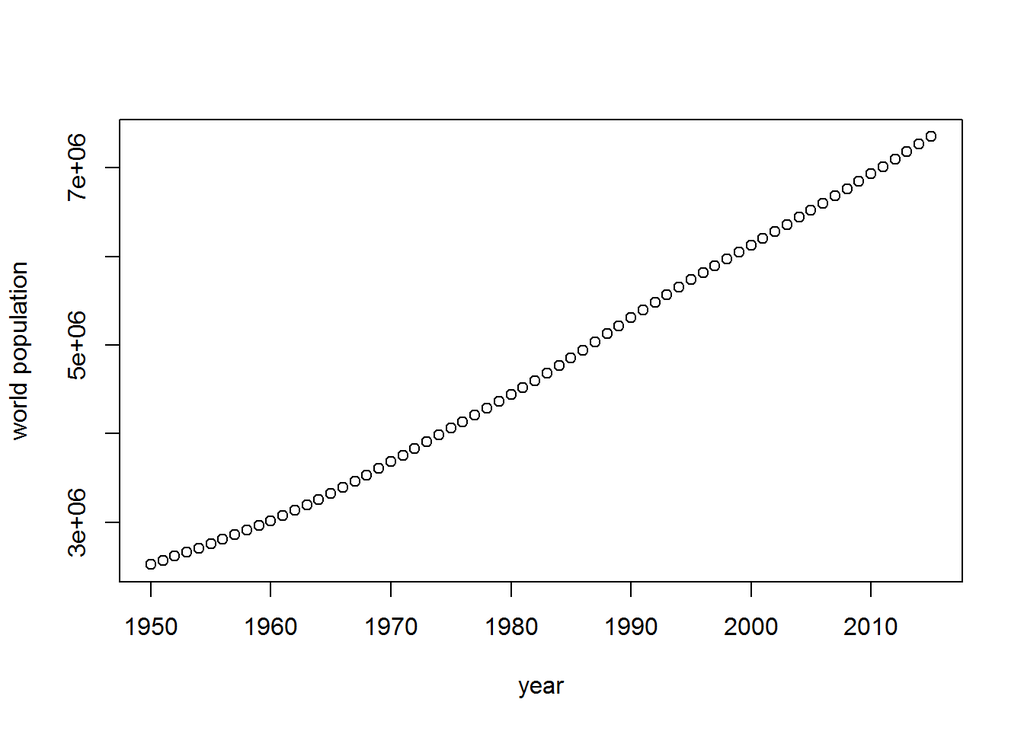

```r
plot(worlddat$Year, worlddat$Population, xlab="year", ylab="world population")
```

## Per capita rates of change

Next, we want to calculate $\frac{dN}{dt}\frac{1}{N}$, the *per capita* rate of change. To do this, we first need to find $N(t-1)$.

```r
# Create t-1 column
worlddat$Year<-as.numeric(worlddat$Year) # change years from characters to numbers

worlddat$YearMinus1<-(worlddat$Year-1) # add a column for the previous year

# Create N_(t-1) column
worlddat$PopMinus1<-worlddat$Population[match(worlddat$YearMinus1, worlddat$Year)]
```

Now, recall that for discrete logistic growth (the model we are applying to this population),
$$\frac{dN}{Ndt}=ln\left( \frac{N_t}{N_{t-x}} \right)*\frac{1}{x}$$
Where $x$ is the time step.

```r
# Get dN/Ndt

worlddat$dNNdt<-log(worlddat$Population/worlddat$PopMinus1)*1/(worlddat$Year-worlddat$YearMinus1)
```

Now, we can plot how per-capita growth rate changes over time and across population sizes.

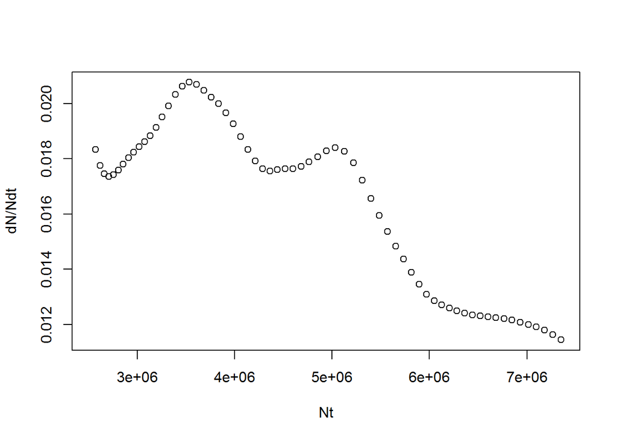

```r
#Plot results
plot(worlddat$Population, worlddat$dNNdt, xlab="Nt", ylab="dN/Ndt")  # N OR N-1 HERE?
```

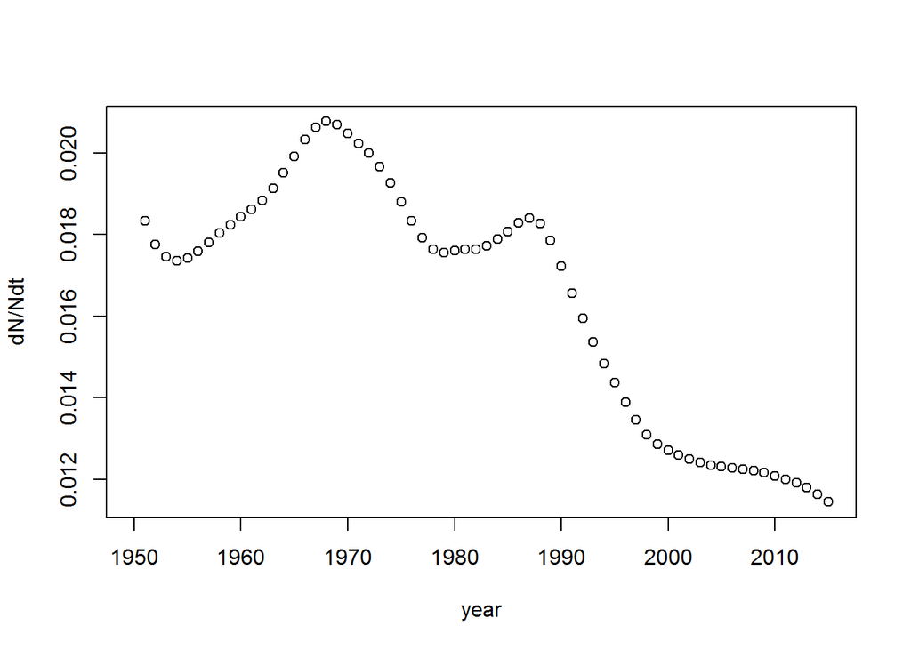

```r
plot(worlddat$Year, worlddat$dNNdt, xlab="year", ylab="dN/Ndt")
```

## Model fitting

Note that there appears to be a change in the direction of the relationship between roughly 1968 and 1969. There are lots of ways that we could account for this, but the simplest is to fit separate linear models for $\frac{dN}{dt}\frac{1}{N}$ against population size for each of the two time windows.

```r
#Fit models
lm_time1<-lm(dNNdt~Population, data=worlddat[worlddat$Year<=1968,])
lm_time2<-lm(dNNdt~Population, data=worlddat[worlddat$Year>1968,])
```

Now, we can evaluate the fit of the two models. What do these plots tell us? If you haven’t seen these sorts of plots before, you can find a good resource [here](http://data.library.virginia.edu/diagnostic-plots/) (http://data.library.virginia.edu/diagnostic-plots/). Very briefly, the upper left plot (residual plot) gives you some information about linear vs. non-linear patterns in your data; the upper right plot (Q-Q or quantile-quantile plot) gives you information about the distribution of your residuals; the lower left plot (scale-location plot) tells you about the variance changes along the range of fitted values; and the lower right plot (the leverage plot) gives you information about the influence of individual data points on the outcome of the regression. You don’t have to exhaustively understand these plots– but know generally what they imply about the reliability of your regression results. The link above has a good explanation of how to interpret these plots.

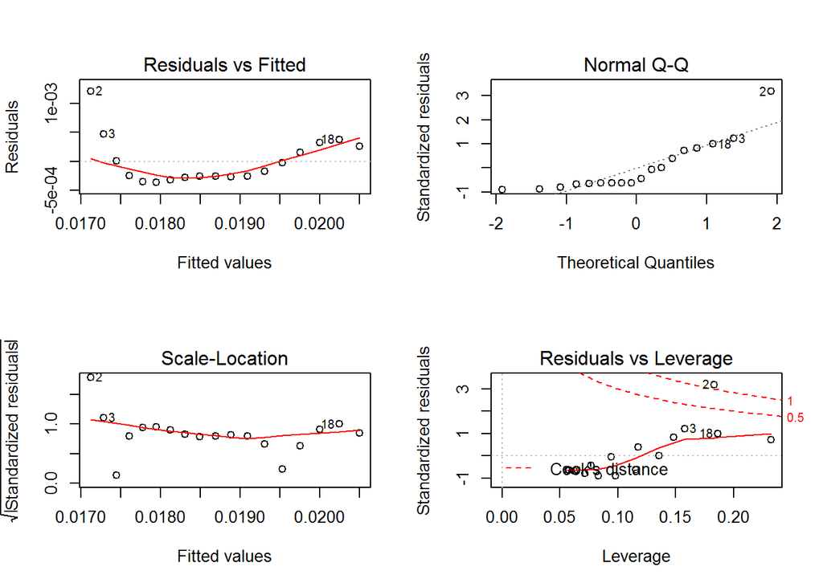

```r
par(mfrow=c(2,2)) #Set parameters for plotting a 2x2 window
plot(lm_time1) # need to run this line at the same time as the one above to get 4-panel plot
```

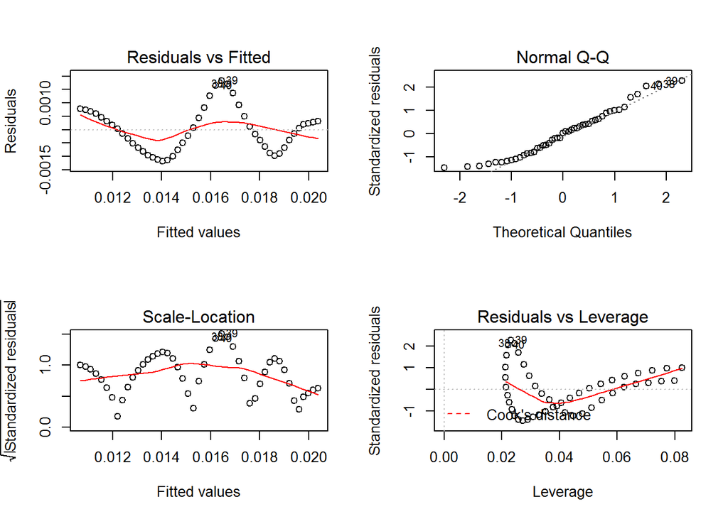

```r
plot(lm_time2)
```

Next, we can interpret the parameter values for these two models. What do these say about population growth? What do the p-values, effect sizes, and R-squared tell us? What kind of growth are we modeling?

```r
summary(lm_time1)
```

```
##
## Call:
## lm(formula = dNNdt ~ Population, data = worlddat[worlddat$Year <=
##     1968, ])
##
## Residuals:
##        Min         1Q     Median         3Q        Max
## -0.0003643 -0.0002655 -0.0002135  0.0002368  0.0012108
##
## Coefficients:
##              Estimate Std. Error t value Pr(>|t|)
## (Intercept) 8.090e-03  1.030e-03   7.855 7.02e-07 ***
## Population  3.512e-09  3.401e-10  10.325 1.76e-08 ***
## ---
## Signif. codes:  0 '***' 0.001 '**' 0.01 '*' 0.05 '.' 0.1 ' ' 1
##
## Residual standard error: 0.0004207 on 16 degrees of freedom
##   (1 observation deleted due to missingness)
## Multiple R-squared:  0.8695, Adjusted R-squared:  0.8613
## F-statistic: 106.6 on 1 and 16 DF,  p-value: 1.758e-08
```

```r
summary(lm_time2)
```

```
##
## Call:
## lm(formula = dNNdt ~ Population, data = worlddat[worlddat$Year >
##     1968, ])
##
## Residuals:
##        Min         1Q     Median         3Q        Max
## -1.181e-03 -6.774e-04  2.511e-05  4.821e-04  1.832e-03
##
## Coefficients:
##               Estimate Std. Error t value Pr(>|t|)
## (Intercept)  2.975e-02  5.968e-04   49.85   <2e-16 ***
## Population  -2.596e-09  1.071e-10  -24.23   <2e-16 ***
## ---
## Signif. codes:  0 '***' 0.001 '**' 0.01 '*' 0.05 '.' 0.1 ' ' 1
##
## Residual standard error: 0.0008187 on 45 degrees of freedom
## Multiple R-squared:  0.9288, Adjusted R-squared:  0.9272
## F-statistic: 587.2 on 1 and 45 DF,  p-value: < 2.2e-16
```

Finally, we can plot the results of fitting the models to visualize the relationships:

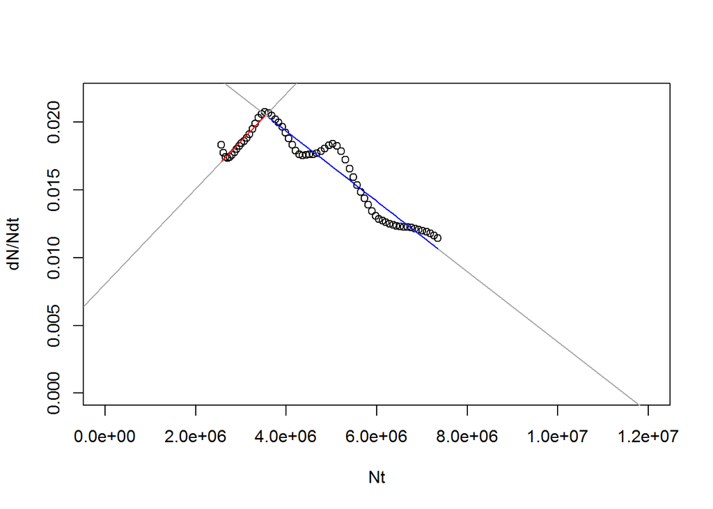

```r
# make base plot
plot(dNNdt~Population, data=worlddat, xlab="Nt", ylab="dN/Ndt", xlim=c(0, 12e6), ylim=c(0,0.022))

# add lines of best fit for both linear models
abline(lm_time1, col="darkgrey")
abline(lm_time2, col="darkgrey")

# add within-sample predictions from both linear models
dNNdt_pred1<-predict(lm_time1)
dNNdt_pred2<-predict(lm_time2)

lines(x=worlddat$Population[worlddat$Year<=1968 & worlddat$Year>1950], y=dNNdt_pred1, col="red") # remove first year, for which there is no prediction (since there was no N-1)
lines(x=worlddat$Population[worlddat$Year>1968], y=dNNdt_pred2, col="blue")
```

## Population trajectory and carrying capacity

Now, what does this graph show us about world population growth? Does this model predict that humans have a carrying capacity? If so, what is it? Does it predict an Allee effect? If so, what is it? Does the graph show in what year we should expect to be near any carrying capacities or Allee points? If not, how would we figure this out?

# Homework Assignment

Now, it’s your turn. While in the example above, we tackled population data for the entire world, you will be investigating individual countries, and comparing and contrasting the drivers of their population growth rates. Your specific tasks for Assignment 1 are as follows:

1. Calculate $dN/Ndt$ for countries of interest.
2. Fit a simple linear model that predicts $dN/Ndt$ as a function of $N$ for both countries. Estimate $K$ for any population that the model predicts will eventually reach $K$.
3. Examine the model fit and discuss whether a linear model is appropriate.
4. Explore how the explanatory variables provided influence $dN/Ndt$ using multiple regression.

The dataset for your assignment is `assignment1_select_countries.csv`.

Your instructions are to fit similar functions to the example above for two different countries: one “Least Developed” or “Developing” nation, and one “Developed” nation. Then, you’ll compare and contrast the population trajectories, and explore what variables might explain them. For this assignment, you will need to submit both figures and text.

We have provided **multiple possible explanatory variables** in the data. **You do not have to use all the variables** in building your multiple regressions, and instead you should try some different specifications that make sense to you. There is no precisely right or wrong way to go about exploring this dataset. We provide the data and some guidelines and questions, but it is up to you how to tackle them. The example above does not have a multiple regression component; you can refresh your R skills in multiple regression with online tutorials like [Allison’s](https://statsthewayilikeit.com/pick-a-method/multiple-regression/).

For figures, make sure you submit graphs that:

1. show whether your models meet the assumptions of the statistical tests that you are using (e.g. the residual plots)
2. show change in population size over time,
3. show the relationship described by your fitted model(s) (e.g. the $\frac{dN}{dt}\frac{1}{N}$ vs. $N(t)$ graph).

Your graphs should be legible and clear (well-captioned, appropriately labeled axes and legends, etc.). Please also include

4. Statistical summary tables of your multiple regressions.

Make sure to provide (A), (B), (C), and (D) for both countries you are studying.

For text, include a 300-500 word description of what your results show. This should include:

5. a description of what you tested,
6. verbal interpretation of your graphs, including whether your data meet the assumptions of a linear model,
7. a verbal interpretation of any summary statistics that describe your model (e.g. p-values, effect sizes, and R-squared), and
8. a short summary of what your results show (what did you discover?) with a focus on the similarities differences between the two countries. Again, these reports do not need to be overly wordy- focus on your quantitative results and what they mean.

**This assignment is due at 11:59pm on February 21.** You should upload your finished project to GauchoSpace. Good luck, and please post to the GauchoSpace with any questions!

### Metadata for the provided dataset

Countries included in the data

| Country | Economic Status |
| --- | --- |
| Gambia | Least Developed |
| Uganda | Least Developed |
| Costa Rica | Developing |
| Honduras | Developing |
| Indonesia | Developing |
| Kenya | Developing |
| Malaysia | Developing |
| Nicaragua | Developing |
| France | Developed |
| Italy | Developed |
| Japan | Developed |
| Spain | Developed |
| United States | Developed |

Variables in the data

| Variable | Description |
| --- | --- |
| country | Country name |
| economic_status | Economic group |
| year | Year |
| food_supply_per_cap | Per capita food supply (log kcal) |
| education | Mean years of education |
| hiv | HIV prevalence (% ages 15-49) |
| population | Populations (thousands) |